# Wrangle & Analyze the WeRateDogs Twitter Archive

# Contents :

- Gathering
- Assessing
- Cleaning
- Storing
- Analysis and Visualization

# Introduction:

We will wrangle (analyze and visualize) a dataset which is the tweet archive of Twitter user @dog_rates, also known as WeRateDogs. WeRateDogs is a Twitter account that rates people's dogs with a humorous comment about the dog.

```python
# import all needed packages
import pandas as pd
import numpy as np
from matplotlib import pyplot as plt
%matplotlib inline
import requests
import json
import os
import seaborn as sns
from IPython.display import Image
```

# 1-Gathering data

1) Twitter archive file:

```python
tweet_archive = pd.read_csv('twitter-archive-enhanced.csv')
tweet_archive.head()
```

|  | tweet_id | in_reply_to_status_id | in_reply_to_user_id | timestamp | source | text | retweeted_status_id | retweeted_status_user_id | retweeted_status_timestamp | expanded_urls | rating_numerator | rating_denominator | name | doggo | floofer | pupper | puppo |
| --- | --- | --- | --- | --- | --- | --- | --- | --- | --- | --- | --- | --- | --- | --- | --- | --- | --- |
| 0 | 8.924210e+17 | NaN | NaN | 2017-08-01 16:23:56 +0000 | <a href="http://twitter.com/download/iphone" r... | This is Phineas. He's a mystical boy. Only eve... | NaN | NaN | NaN | https://twitter.com/dog_rates/status/892420643... | 13 | 10 | Phineas | None | None | None | None |
| 1 | 8.921770e+17 | NaN | NaN | 2017-08-01 00:17:27 +0000 | <a href="http://twitter.com/download/iphone" r... | This is Tilly. She's just checking pup on you.... | NaN | NaN | NaN | https://twitter.com/dog_rates/status/892177421... | 13 | 10 | Tilly | None | None | None | None |
| 2 | 8.918150e+17 | NaN | NaN | 2017-07-31 00:18:03 +0000 | <a href="http://twitter.com/download/iphone" r... | This is Archie. He is a rare Norwegian Pouncin... | NaN | NaN | NaN | https://twitter.com/dog_rates/status/891815181... | 12 | 10 | Archie | None | None | None | None |
| 3 | 8.916900e+17 | NaN | NaN | 2017-07-30 15:58:51 +0000 | <a href="http://twitter.com/download/iphone" r... | This is Darla. She commenced a snooze mid meal... | NaN | NaN | NaN | https://twitter.com/dog_rates/status/891689557... | 13 | 10 | Darla | None | None | None | None |
| 4 | 8.913280e+17 | NaN | NaN | 2017-07-29 16:00:24 +0000 | <a href="http://twitter.com/download/iphone" r... | This is Franklin. He would like you to stop ca... | NaN | NaN | NaN | https://twitter.com/dog_rates/status/891327558... | 12 | 10 | Franklin | None | None | None | None |

2) Image prediction data:

```python
# Gathering the Image Predictions File from a url online
url ="https://d17h27t6h515a5.cloudfront.net/topher/2017/August/599fd2ad_image-predictions/image-predictions.tsv"
response = requests.get(url)

#creat file
with open('image-predictions.tsv',mode='wb') as file:
    file.write(response.content)

image_predictions = pd.read_csv('image-predictions.tsv', sep='\t')
```

```python
tweet=pd.read_json('tweet-json.txt', lines=True)
tweet
```

|  | created_at | id | id_str | full_text | truncated | display_text_range | entities | extended_entities | source | in_reply_to_status_id | ... | favorite_count | favorited | retweeted | possibly_sensitive | possibly_sensitive_appealable | lang | retweeted_status | quoted_status_id | quoted_status_id_str | quoted_status |
| --- | --- | --- | --- | --- | --- | --- | --- | --- | --- | --- | --- | --- | --- | --- | --- | --- | --- | --- | --- | --- | --- |
| 0 | 2017-08-01 16:23:56+00:00 | 892420643555336193 | 892420643555336192 | This is Phineas. He's a mystical boy. Only eve... | False | [0, 85] | {'hashtags': [], 'symbols': [], 'user_mentions... | {'media': [{'id': 892420639486877696, 'id_str'... | <a href="http://twitter.com/download/iphone" r... | NaN | ... | 39467 | False | False | 0.0 | 0.0 | en | NaN | NaN | NaN | NaN |
| 1 | 2017-08-01 00:17:27+00:00 | 892177421306343426 | 892177421306343424 | This is Tilly. She's just checking pup on you.... | False | [0, 138] | {'hashtags': [], 'symbols': [], 'user_mentions... | {'media': [{'id': 892177413194625024, 'id_str'... | <a href="http://twitter.com/download/iphone" r... | NaN | ... | 33819 | False | False | 0.0 | 0.0 | en | NaN | NaN | NaN | NaN |
| 2 | 2017-07-31 00:18:03+00:00 | 891815181378084864 | 891815181378084864 | This is Archie. He is a rare Norwegian Pouncin... | False | [0, 121] | {'hashtags': [], 'symbols': [], 'user_mentions... | {'media': [{'id': 891815175371796480, 'id_str'... | <a href="http://twitter.com/download/iphone" r... | NaN | ... | 25461 | False | False | 0.0 | 0.0 | en | NaN | NaN | NaN | NaN |
| 3 | 2017-07-30 15:58:51+00:00 | 891689557279858688 | 891689557279858688 | This is Darla. She commenced a snooze mid meal... | False | [0, 79] | {'hashtags': [], 'symbols': [], 'user_mentions... | {'media': [{'id': 891689552724799489, 'id_str'... | <a href="http://twitter.com/download/iphone" r... | NaN | ... | 42908 | False | False | 0.0 | 0.0 | en | NaN | NaN | NaN | NaN |
| 4 | 2017-07-29 16:00:24+00:00 | 891327558926688256 | 891327558926688256 | This is Franklin. He would like you to stop ca... | False | [0, 138] | {'hashtags': [{'text': 'BarkWeek', 'indices': ... | {'media': [{'id': 891327551943041024, 'id_str'... | <a href="http://twitter.com/download/iphone" r... | NaN | ... | 41048 | False | False | 0.0 | 0.0 | en | NaN | NaN | NaN | NaN |
| ... | ... | ... | ... | ... | ... | ... | ... | ... | ... | ... | ... | ... | ... | ... | ... | ... | ... | ... | ... | ... | ... |
| 2349 | 2015-11-16 00:24:50+00:00 | 666049248165822465 | 666049248165822464 | Here we have a 1949 1st generation vulpix. Enj... | False | [0, 120] | {'hashtags': [], 'symbols': [], 'user_mentions... | {'media': [{'id': 666049244999131136, 'id_str'... | <a href="http://twitter.com/download/iphone" r... | NaN | ... | 111 | False | False | 0.0 | 0.0 | en | NaN | NaN | NaN | NaN |
| 2350 | 2015-11-16 00:04:52+00:00 | 666044226329800704 | 666044226329800704 | This is a purebred Piers Morgan. Loves to Netf... | False | [0, 137] | {'hashtags': [], 'symbols': [], 'user_mentions... | {'media': [{'id': 666044217047650304, 'id_str'... | <a href="http://twitter.com/download/iphone" r... | NaN | ... | 311 | False | False | 0.0 | 0.0 | en | NaN | NaN | NaN | NaN |
| 2351 | 2015-11-15 23:21:54+00:00 | 666033412701032449 | 666033412701032448 | Here is a very happy pup. Big fan of well-main... | False | [0, 130] | {'hashtags': [], 'symbols': [], 'user_mentions... | {'media': [{'id': 666033409081393153, 'id_str'... | <a href="http://twitter.com/download/iphone" r... | NaN | ... | 128 | False | False | 0.0 | 0.0 | en | NaN | NaN | NaN | NaN |
| 2352 | 2015-11-15 23:05:30+00:00 | 666029285002620928 | 666029285002620928 | This is a western brown Mitsubishi terrier. Up... | False | [0, 139] | {'hashtags': [], 'symbols': [], 'user_mentions... | {'media': [{'id': 666029276303482880, 'id_str'... | <a href="http://twitter.com/download/iphone" r... | NaN | ... | 132 | False | False | 0.0 | 0.0 | en | NaN | NaN | NaN | NaN |
| 2353 | 2015-11-15 22:32:08+00:00 | 666020888022790149 | 666020888022790144 | Here we have a Japanese Irish Setter. Lost eye... | False | [0, 131] | {'hashtags': [], 'symbols': [], 'user_mentions... | {'media': [{'id': 666020881337073664, 'id_str'... | <a href="http://twitter.com/download/iphone" r... | NaN | ... | 2535 | False | False | 0.0 | 0.0 | en | NaN | NaN | NaN | NaN |

2354 rows × 31 columns

3) connect to twitter API :

```python
import tweepy
consumer_key = 'xxxx xxxx xxxx'
consumer_secret = 'xxxx xxxx xxxx'
access_token = 'xxxx xxxx xxxx'
access_secret = 'xxxx xxxx xxxx'

auth = tweepy.OAuthHandler(consumer_key, consumer_secret)
auth.set_access_token(access_token, access_secret)

api = tweepy.API(auth)
```

```python
#from tweepy import OAuthHandler
#from timeit import default_timer as timer

# Query Twitter API for each tweet in the Twitter archive and save JSON in a text file
# These are hidden to comply with Twitter's API terms and conditions
#consumer_key = 'HIDDEN'
#consumer_secret = 'HIDDEN'
#access_token = 'HIDDEN'
#access_secret = 'HIDDEN'

#auth = OAuthHandler(consumer_key, consumer_secret)
#auth.set_access_token(access_token, access_secret)

#api = tweepy.API(auth, wait_on_rate_limit=True)

# NOTE TO STUDENT WITH MOBILE VERIFICATION ISSUES:
# df_1 is a DataFrame with the twitter_archive_enhanced.csv file. You may have to
# change line 17 to match the name of your DataFrame with twitter_archive_enhanced.csv
# NOTE TO REVIEWER: this student had mobile verification issues so the following
# Twitter API code was sent to this student from a Udacity instructor
# Tweet IDs for which to gather additional data via Twitter's API
#tweet_ids = tweet_archive.tweet_id.values
#len(tweet_ids)

# Query Twitter's API for JSON data for each tweet ID in the Twitter archive
#count = 0
#fails_dict = {}
#start = timer()
# Save each tweet's returned JSON as a new line in a .txt file
#with open('tweet_json.txt', 'w') as outfile:
    # This loop will likely take 20-30 minutes to run because of Twitter's rate limit
    #for tweet_id in tweet_ids:
       # count += 1
       # print(str(count) + ": " + str(tweet_id))
       # try:
    #    tweet = api.get_status(tweet_id, tweet_mode='extended')
      #      print("Success")
      #      json.dump(tweet._json, outfile)
      #      outfile.write('\n')
      #  except tweepy.TweepError as e:
      #      print("Fail")
      #      fails_dict[tweet_id] = e
      #      pass
#end = timer()
#print(end - start)
#print(fails_dict)
```

# 2-Assessing Data

```python
tweet_archive.info()
```

```
<class 'pandas.core.frame.DataFrame'>
RangeIndex: 2356 entries, 0 to 2355
Data columns (total 17 columns):
 #   Column                      Non-Null Count  Dtype
---  ------                      --------------  -----
 0   tweet_id                    2356 non-null   float64
 1   in_reply_to_status_id       78 non-null     float64
 2   in_reply_to_user_id         78 non-null     float64
 3   timestamp                   2356 non-null   object
 4   source                      2356 non-null   object
 5   text                        2356 non-null   object
 6   retweeted_status_id         181 non-null    float64
 7   retweeted_status_user_id    181 non-null    float64
 8   retweeted_status_timestamp  181 non-null    object
 9   expanded_urls               2297 non-null   object
 10  rating_numerator            2356 non-null   int64
 11  rating_denominator          2356 non-null   int64
 12  name                        2356 non-null   object
 13  doggo                       2356 non-null   object
 14  floofer                     2356 non-null   object
 15  pupper                      2356 non-null   object
 16  puppo                       2356 non-null   object
dtypes: float64(5), int64(2), object(10)
memory usage: 313.0+ KB
```

```python
tweet_archive.head()
```

|  | tweet_id | in_reply_to_status_id | in_reply_to_user_id | timestamp | source | text | retweeted_status_id | retweeted_status_user_id | retweeted_status_timestamp | expanded_urls | rating_numerator | rating_denominator | name | doggo | floofer | pupper | puppo |
| --- | --- | --- | --- | --- | --- | --- | --- | --- | --- | --- | --- | --- | --- | --- | --- | --- | --- |
| 0 | 8.924210e+17 | NaN | NaN | 2017-08-01 16:23:56 +0000 | <a href="http://twitter.com/download/iphone" r... | This is Phineas. He's a mystical boy. Only eve... | NaN | NaN | NaN | https://twitter.com/dog_rates/status/892420643... | 13 | 10 | Phineas | None | None | None | None |
| 1 | 8.921770e+17 | NaN | NaN | 2017-08-01 00:17:27 +0000 | <a href="http://twitter.com/download/iphone" r... | This is Tilly. She's just checking pup on you.... | NaN | NaN | NaN | https://twitter.com/dog_rates/status/892177421... | 13 | 10 | Tilly | None | None | None | None |
| 2 | 8.918150e+17 | NaN | NaN | 2017-07-31 00:18:03 +0000 | <a href="http://twitter.com/download/iphone" r... | This is Archie. He is a rare Norwegian Pouncin... | NaN | NaN | NaN | https://twitter.com/dog_rates/status/891815181... | 12 | 10 | Archie | None | None | None | None |
| 3 | 8.916900e+17 | NaN | NaN | 2017-07-30 15:58:51 +0000 | <a href="http://twitter.com/download/iphone" r... | This is Darla. She commenced a snooze mid meal... | NaN | NaN | NaN | https://twitter.com/dog_rates/status/891689557... | 13 | 10 | Darla | None | None | None | None |
| 4 | 8.913280e+17 | NaN | NaN | 2017-07-29 16:00:24 +0000 | <a href="http://twitter.com/download/iphone" r... | This is Franklin. He would like you to stop ca... | NaN | NaN | NaN | https://twitter.com/dog_rates/status/891327558... | 12 | 10 | Franklin | None | None | None | None |

```python
image_predictions.info()
```

```
<class 'pandas.core.frame.DataFrame'>
RangeIndex: 2075 entries, 0 to 2074
Data columns (total 12 columns):
 #   Column    Non-Null Count  Dtype
---  ------    --------------  -----
 0   tweet_id  2075 non-null   int64
 1   jpg_url   2075 non-null   object
 2   img_num   2075 non-null   int64
 3   p1        2075 non-null   object
 4   p1_conf   2075 non-null   float64
 5   p1_dog    2075 non-null   bool
 6   p2        2075 non-null   object
 7   p2_conf   2075 non-null   float64
 8   p2_dog    2075 non-null   bool
 9   p3        2075 non-null   object
 10  p3_conf   2075 non-null   float64
 11  p3_dog    2075 non-null   bool
dtypes: bool(3), float64(3), int64(2), object(4)
memory usage: 152.1+ KB
```

```python
tweet.info()
```

```
<class 'pandas.core.frame.DataFrame'>
RangeIndex: 2354 entries, 0 to 2353
Data columns (total 31 columns):
 #   Column                         Non-Null Count  Dtype
---  ------                         --------------  -----
 0   created_at                     2354 non-null   datetime64[ns, UTC]
 1   id                             2354 non-null   int64
 2   id_str                         2354 non-null   int64
 3   full_text                      2354 non-null   object
 4   truncated                      2354 non-null   bool
 5   display_text_range             2354 non-null   object
 6   entities                       2354 non-null   object
 7   extended_entities              2073 non-null   object
 8   source                         2354 non-null   object
 9   in_reply_to_status_id          78 non-null     float64
```

[output cut: 23 more lines]

```python
tweet.head()
```

|  | created_at | id | id_str | full_text | truncated | display_text_range | entities | extended_entities | source | in_reply_to_status_id | ... | favorite_count | favorited | retweeted | possibly_sensitive | possibly_sensitive_appealable | lang | retweeted_status | quoted_status_id | quoted_status_id_str | quoted_status |
| --- | --- | --- | --- | --- | --- | --- | --- | --- | --- | --- | --- | --- | --- | --- | --- | --- | --- | --- | --- | --- | --- |
| 0 | 2017-08-01 16:23:56+00:00 | 892420643555336193 | 892420643555336192 | This is Phineas. He's a mystical boy. Only eve... | False | [0, 85] | {'hashtags': [], 'symbols': [], 'user_mentions... | {'media': [{'id': 892420639486877696, 'id_str'... | <a href="http://twitter.com/download/iphone" r... | NaN | ... | 39467 | False | False | 0.0 | 0.0 | en | NaN | NaN | NaN | NaN |
| 1 | 2017-08-01 00:17:27+00:00 | 892177421306343426 | 892177421306343424 | This is Tilly. She's just checking pup on you.... | False | [0, 138] | {'hashtags': [], 'symbols': [], 'user_mentions... | {'media': [{'id': 892177413194625024, 'id_str'... | <a href="http://twitter.com/download/iphone" r... | NaN | ... | 33819 | False | False | 0.0 | 0.0 | en | NaN | NaN | NaN | NaN |
| 2 | 2017-07-31 00:18:03+00:00 | 891815181378084864 | 891815181378084864 | This is Archie. He is a rare Norwegian Pouncin... | False | [0, 121] | {'hashtags': [], 'symbols': [], 'user_mentions... | {'media': [{'id': 891815175371796480, 'id_str'... | <a href="http://twitter.com/download/iphone" r... | NaN | ... | 25461 | False | False | 0.0 | 0.0 | en | NaN | NaN | NaN | NaN |
| 3 | 2017-07-30 15:58:51+00:00 | 891689557279858688 | 891689557279858688 | This is Darla. She commenced a snooze mid meal... | False | [0, 79] | {'hashtags': [], 'symbols': [], 'user_mentions... | {'media': [{'id': 891689552724799489, 'id_str'... | <a href="http://twitter.com/download/iphone" r... | NaN | ... | 42908 | False | False | 0.0 | 0.0 | en | NaN | NaN | NaN | NaN |
| 4 | 2017-07-29 16:00:24+00:00 | 891327558926688256 | 891327558926688256 | This is Franklin. He would like you to stop ca... | False | [0, 138] | {'hashtags': [{'text': 'BarkWeek', 'indices': ... | {'media': [{'id': 891327551943041024, 'id_str'... | <a href="http://twitter.com/download/iphone" r... | NaN | ... | 41048 | False | False | 0.0 | 0.0 | en | NaN | NaN | NaN | NaN |

5 rows × 31 columns

```python
tweet.describe()
```

|  | id | id_str | in_reply_to_status_id | in_reply_to_status_id_str | in_reply_to_user_id | in_reply_to_user_id_str | geo | coordinates | contributors | retweet_count | favorite_count | possibly_sensitive | possibly_sensitive_appealable | quoted_status_id | quoted_status_id_str |
| --- | --- | --- | --- | --- | --- | --- | --- | --- | --- | --- | --- | --- | --- | --- | --- |
| count | 2.354000e+03 | 2.354000e+03 | 7.800000e+01 | 7.800000e+01 | 7.800000e+01 | 7.800000e+01 | 0.0 | 0.0 | 0.0 | 2354.000000 | 2354.000000 | 2211.0 | 2211.0 | 2.900000e+01 | 2.900000e+01 |
| mean | 7.426978e+17 | 7.426978e+17 | 7.455079e+17 | 7.455079e+17 | 2.014171e+16 | 2.014171e+16 | NaN | NaN | NaN | 3164.797366 | 8080.968564 | 0.0 | 0.0 | 8.162686e+17 | 8.162686e+17 |
| std | 6.852812e+16 | 6.852812e+16 | 7.582492e+16 | 7.582492e+16 | 1.252797e+17 | 1.252797e+17 | NaN | NaN | NaN | 5284.770364 | 11814.771334 | 0.0 | 0.0 | 6.164161e+16 | 6.164161e+16 |
| min | 6.660209e+17 | 6.660209e+17 | 6.658147e+17 | 6.658147e+17 | 1.185634e+07 | 1.185634e+07 | NaN | NaN | NaN | 0.000000 | 0.000000 | 0.0 | 0.0 | 6.721083e+17 | 6.721083e+17 |
| 25% | 6.783975e+17 | 6.783975e+17 | 6.757419e+17 | 6.757419e+17 | 3.086374e+08 | 3.086374e+08 | NaN | NaN | NaN | 624.500000 | 1415.000000 | 0.0 | 0.0 | 7.888183e+17 | 7.888183e+17 |
| 50% | 7.194596e+17 | 7.194596e+17 | 7.038708e+17 | 7.038708e+17 | 4.196984e+09 | 4.196984e+09 | NaN | NaN | NaN | 1473.500000 | 3603.500000 | 0.0 | 0.0 | 8.340867e+17 | 8.340867e+17 |
| 75% | 7.993058e+17 | 7.993058e+17 | 8.257804e+17 | 8.257804e+17 | 4.196984e+09 | 4.196984e+09 | NaN | NaN | NaN | 3652.000000 | 10122.250000 | 0.0 | 0.0 | 8.664587e+17 | 8.664587e+17 |
| max | 8.924206e+17 | 8.924206e+17 | 8.862664e+17 | 8.862664e+17 | 8.405479e+17 | 8.405479e+17 | NaN | NaN | NaN | 79515.000000 | 132810.000000 | 0.0 | 0.0 | 8.860534e+17 | 8.860534e+17 |

```python
tweet.retweeted.value_counts()
```

```
False    2354
Name: retweeted, dtype: int64
```

```python
tweet_archive.isnull().sum()
```

```
tweet_id                         0
in_reply_to_status_id         2278
in_reply_to_user_id           2278
timestamp                        0
source                           0
text                             0
retweeted_status_id           2175
retweeted_status_user_id      2175
retweeted_status_timestamp    2175
expanded_urls                   59
rating_numerator                 0
rating_denominator               0
name                             0
doggo                            0
floofer                          0
pupper                           0
puppo                            0
dtype: int64
```

```python
sum(image_predictions.jpg_url.duplicated())
```

```
66
```

# Tidiness:

1- rating_numerator and rating_denominator can be in one column.

2- doggo , floofer , pupper , and puppo are all dog type so we need to merge them in one column.

# Quality:

1- Wrong dog names sometimes "a".

2- Empty columns in twitter_archive

3- Some duplicated records in twitter archive because of retweets.

4- 'timestamp' has wrong datatype. It is a object and should be datetime .

5- 'id' name should be change to 'tweet_id' in (tweet) table .

7- 'tweet_id' has wrong datatype it is int and should be a string in (image_predictions) table .

8- Drop the duplicated rows in (image_predictions) table.

9- "jpg_url" information that don't benefit any thing to our analysis so we don't need it.

# 3-Cleaning Data

```python
# we need to copy the datasets .
tweet_archive_clean = tweet_archive.copy()
image_predictions_clean = image_predictions.copy()
tweet_clean = tweet.copy()
```

```python
tweet_archive.info()
```

```
<class 'pandas.core.frame.DataFrame'>
RangeIndex: 2356 entries, 0 to 2355
Data columns (total 17 columns):
 #   Column                      Non-Null Count  Dtype
---  ------                      --------------  -----
 0   tweet_id                    2356 non-null   float64
 1   in_reply_to_status_id       78 non-null     float64
 2   in_reply_to_user_id         78 non-null     float64
 3   timestamp                   2356 non-null   object
 4   source                      2356 non-null   object
 5   text                        2356 non-null   object
 6   retweeted_status_id         181 non-null    float64
 7   retweeted_status_user_id    181 non-null    float64
 8   retweeted_status_timestamp  181 non-null    object
 9   expanded_urls               2297 non-null   object
 10  rating_numerator            2356 non-null   int64
 11  rating_denominator          2356 non-null   int64
 12  name                        2356 non-null   object
 13  doggo                       2356 non-null   object
 14  floofer                     2356 non-null   object
 15  pupper                      2356 non-null   object
 16  puppo                       2356 non-null   object
dtypes: float64(5), int64(2), object(10)
memory usage: 313.0+ KB
```

## Define (Tidiness)

- rating_numerator and rating_denominator can be combined in one column.

## Code

```python
tweet_archive_clean['rating_percent'] = tweet_archive_clean.rating_numerator/tweet_archive_clean.rating_denominator
tweet_archive_clean
```

|  | tweet_id | in_reply_to_status_id | in_reply_to_user_id | timestamp | source | text | retweeted_status_id | retweeted_status_user_id | retweeted_status_timestamp | expanded_urls | rating_numerator | rating_denominator | name | doggo | floofer | pupper | puppo | rating_percent |
| --- | --- | --- | --- | --- | --- | --- | --- | --- | --- | --- | --- | --- | --- | --- | --- | --- | --- | --- |
| 0 | 8.924210e+17 | NaN | NaN | 2017-08-01 16:23:56 +0000 | <a href="http://twitter.com/download/iphone" r... | This is Phineas. He's a mystical boy. Only eve... | NaN | NaN | NaN | https://twitter.com/dog_rates/status/892420643... | 13 | 10 | Phineas | None | None | None | None | 1.3 |
| 1 | 8.921770e+17 | NaN | NaN | 2017-08-01 00:17:27 +0000 | <a href="http://twitter.com/download/iphone" r... | This is Tilly. She's just checking pup on you.... | NaN | NaN | NaN | https://twitter.com/dog_rates/status/892177421... | 13 | 10 | Tilly | None | None | None | None | 1.3 |
| 2 | 8.918150e+17 | NaN | NaN | 2017-07-31 00:18:03 +0000 | <a href="http://twitter.com/download/iphone" r... | This is Archie. He is a rare Norwegian Pouncin... | NaN | NaN | NaN | https://twitter.com/dog_rates/status/891815181... | 12 | 10 | Archie | None | None | None | None | 1.2 |
| 3 | 8.916900e+17 | NaN | NaN | 2017-07-30 15:58:51 +0000 | <a href="http://twitter.com/download/iphone" r... | This is Darla. She commenced a snooze mid meal... | NaN | NaN | NaN | https://twitter.com/dog_rates/status/891689557... | 13 | 10 | Darla | None | None | None | None | 1.3 |
| 4 | 8.913280e+17 | NaN | NaN | 2017-07-29 16:00:24 +0000 | <a href="http://twitter.com/download/iphone" r... | This is Franklin. He would like you to stop ca... | NaN | NaN | NaN | https://twitter.com/dog_rates/status/891327558... | 12 | 10 | Franklin | None | None | None | None | 1.2 |
| ... | ... | ... | ... | ... | ... | ... | ... | ... | ... | ... | ... | ... | ... | ... | ... | ... | ... | ... |
| 2351 | 6.660490e+17 | NaN | NaN | 2015-11-16 00:24:50 +0000 | <a href="http://twitter.com/download/iphone" r... | Here we have a 1949 1st generation vulpix. Enj... | NaN | NaN | NaN | https://twitter.com/dog_rates/status/666049248... | 5 | 10 | None | None | None | None | None | 0.5 |
| 2352 | 6.660440e+17 | NaN | NaN | 2015-11-16 00:04:52 +0000 | <a href="http://twitter.com/download/iphone" r... | This is a purebred Piers Morgan. Loves to Netf... | NaN | NaN | NaN | https://twitter.com/dog_rates/status/666044226... | 6 | 10 | a | None | None | None | None | 0.6 |
| 2353 | 6.660330e+17 | NaN | NaN | 2015-11-15 23:21:54 +0000 | <a href="http://twitter.com/download/iphone" r... | Here is a very happy pup. Big fan of well-main... | NaN | NaN | NaN | https://twitter.com/dog_rates/status/666033412... | 9 | 10 | a | None | None | None | None | 0.9 |
| 2354 | 6.660290e+17 | NaN | NaN | 2015-11-15 23:05:30 +0000 | <a href="http://twitter.com/download/iphone" r... | This is a western brown Mitsubishi terrier. Up... | NaN | NaN | NaN | https://twitter.com/dog_rates/status/666029285... | 7 | 10 | a | None | None | None | None | 0.7 |
| 2355 | 6.660210e+17 | NaN | NaN | 2015-11-15 22:32:08 +0000 | <a href="http://twitter.com/download/iphone" r... | Here we have a Japanese Irish Setter. Lost eye... | NaN | NaN | NaN | https://twitter.com/dog_rates/status/666020888... | 8 | 10 | None | None | None | None | None | 0.8 |

2356 rows × 18 columns

```python
tweet_archive_clean.drop(columns=['rating_numerator','rating_denominator'], inplace=True)
```

## Test

```python
tweet_archive_clean
```

|  | tweet_id | in_reply_to_status_id | in_reply_to_user_id | timestamp | source | text | retweeted_status_id | retweeted_status_user_id | retweeted_status_timestamp | expanded_urls | name | doggo | floofer | pupper | puppo | rating_percent |
| --- | --- | --- | --- | --- | --- | --- | --- | --- | --- | --- | --- | --- | --- | --- | --- | --- |
| 0 | 8.924210e+17 | NaN | NaN | 2017-08-01 16:23:56 +0000 | <a href="http://twitter.com/download/iphone" r... | This is Phineas. He's a mystical boy. Only eve... | NaN | NaN | NaN | https://twitter.com/dog_rates/status/892420643... | Phineas | None | None | None | None | 1.3 |
| 1 | 8.921770e+17 | NaN | NaN | 2017-08-01 00:17:27 +0000 | <a href="http://twitter.com/download/iphone" r... | This is Tilly. She's just checking pup on you.... | NaN | NaN | NaN | https://twitter.com/dog_rates/status/892177421... | Tilly | None | None | None | None | 1.3 |
| 2 | 8.918150e+17 | NaN | NaN | 2017-07-31 00:18:03 +0000 | <a href="http://twitter.com/download/iphone" r... | This is Archie. He is a rare Norwegian Pouncin... | NaN | NaN | NaN | https://twitter.com/dog_rates/status/891815181... | Archie | None | None | None | None | 1.2 |
| 3 | 8.916900e+17 | NaN | NaN | 2017-07-30 15:58:51 +0000 | <a href="http://twitter.com/download/iphone" r... | This is Darla. She commenced a snooze mid meal... | NaN | NaN | NaN | https://twitter.com/dog_rates/status/891689557... | Darla | None | None | None | None | 1.3 |
| 4 | 8.913280e+17 | NaN | NaN | 2017-07-29 16:00:24 +0000 | <a href="http://twitter.com/download/iphone" r... | This is Franklin. He would like you to stop ca... | NaN | NaN | NaN | https://twitter.com/dog_rates/status/891327558... | Franklin | None | None | None | None | 1.2 |
| ... | ... | ... | ... | ... | ... | ... | ... | ... | ... | ... | ... | ... | ... | ... | ... | ... |
| 2351 | 6.660490e+17 | NaN | NaN | 2015-11-16 00:24:50 +0000 | <a href="http://twitter.com/download/iphone" r... | Here we have a 1949 1st generation vulpix. Enj... | NaN | NaN | NaN | https://twitter.com/dog_rates/status/666049248... | None | None | None | None | None | 0.5 |
| 2352 | 6.660440e+17 | NaN | NaN | 2015-11-16 00:04:52 +0000 | <a href="http://twitter.com/download/iphone" r... | This is a purebred Piers Morgan. Loves to Netf... | NaN | NaN | NaN | https://twitter.com/dog_rates/status/666044226... | a | None | None | None | None | 0.6 |
| 2353 | 6.660330e+17 | NaN | NaN | 2015-11-15 23:21:54 +0000 | <a href="http://twitter.com/download/iphone" r... | Here is a very happy pup. Big fan of well-main... | NaN | NaN | NaN | https://twitter.com/dog_rates/status/666033412... | a | None | None | None | None | 0.9 |
| 2354 | 6.660290e+17 | NaN | NaN | 2015-11-15 23:05:30 +0000 | <a href="http://twitter.com/download/iphone" r... | This is a western brown Mitsubishi terrier. Up... | NaN | NaN | NaN | https://twitter.com/dog_rates/status/666029285... | a | None | None | None | None | 0.7 |
| 2355 | 6.660210e+17 | NaN | NaN | 2015-11-15 22:32:08 +0000 | <a href="http://twitter.com/download/iphone" r... | Here we have a Japanese Irish Setter. Lost eye... | NaN | NaN | NaN | https://twitter.com/dog_rates/status/666020888... | None | None | None | None | None | 0.8 |

2356 rows × 16 columns

## Define

- doggo , floofer , pupper , and puppo are all dog type so we need to merge them in one column.

## Code

```python
tweet_archive_clean.replace('None', np.nan, inplace=True)
tweet_archive_clean['dog_stage'] = tweet_archive_clean[['doggo', 'floofer', 'pupper', 'puppo']].fillna('').sum(axis=1).astype(str)


tweet_archive_clean.loc[tweet_archive_clean['dog_stage'] == 'doggopuppo', 'dog_stage'] = 'doggo , puppo'
tweet_archive_clean.loc[tweet_archive_clean['dog_stage'] == 'doggofloofer', 'dog_stage'] = 'doggo , floofer'
tweet_archive_clean.loc[tweet_archive_clean['dog_stage'] == 'doggopupper', 'dog_stage'] = 'doggo , pupper'
tweet_archive_clean = tweet_archive_clean.drop(['doggo', 'floofer', 'pupper', 'puppo'] , axis = 1)
```

## Test

```python
tweet_archive_clean.info()
```

```
<class 'pandas.core.frame.DataFrame'>
RangeIndex: 2356 entries, 0 to 2355
Data columns (total 13 columns):
 #   Column                      Non-Null Count  Dtype
---  ------                      --------------  -----
 0   tweet_id                    2356 non-null   float64
 1   in_reply_to_status_id       78 non-null     float64
 2   in_reply_to_user_id         78 non-null     float64
 3   timestamp                   2356 non-null   object
 4   source                      2356 non-null   object
 5   text                        2356 non-null   object
 6   retweeted_status_id         181 non-null    float64
 7   retweeted_status_user_id    181 non-null    float64
 8   retweeted_status_timestamp  181 non-null    object
 9   expanded_urls               2297 non-null   object
 10  name                        1611 non-null   object
 11  rating_percent              2356 non-null   float64
 12  dog_stage                   2356 non-null   object
dtypes: float64(6), object(7)
memory usage: 239.4+ KB
```

```python
tweet_archive_clean.dog_stage.value_counts()
```

```
                   1976
pupper              245
doggo                83
puppo                29
doggo , pupper       12
floofer               9
doggo , puppo         1
doggo , floofer       1
Name: dog_stage, dtype: int64
```

## Define (Quality)

- Fix the wrong dog names.

## Code

```python
tweet_archive_clean.name.value_counts()
```

```
a          55
Charlie    12
Lucy       11
Cooper     11
Oliver     11
           ..
Kloey       1
Strudel     1
Torque      1
Cedrick     1
Lucia       1
Name: name, Length: 956, dtype: int64
```

```python
tweet_archive_clean.name = tweet_archive_clean.name.replace('a', np.nan)
tweet_archive_clean.name = tweet_archive_clean.name.replace('None', np.nan)
```

## Test

```python
tweet_archive_clean.name.value_counts()
```

```
Charlie    12
Lucy       11
Cooper     11
Oliver     11
Penny      10
           ..
Kloey       1
Strudel     1
Torque      1
Cedrick     1
Lucia       1
Name: name, Length: 955, dtype: int64
```

## Define

- Empty columns in twitter_archive
- Some duplicated records in twitter archive because of retweets, i will Remove the retweets and their associated columns

## Code

```python
# filter the rows where the retweet columns are empty
tweet_archive_clean = tweet_archive_clean[tweet_archive_clean.retweeted_status_id.isnull()]

# drop the retweet related columns
tweet_archive_clean = tweet_archive_clean.drop(['in_reply_to_status_id', 'in_reply_to_user_id', 'retweeted_status_id',
                                    'retweeted_status_user_id', 'retweeted_status_timestamp'], axis=1)
```

```python
tweet_archive_clean = tweet_archive_clean.reset_index()
```

## Test

```python
tweet_archive_clean.info()
```

```
<class 'pandas.core.frame.DataFrame'>
RangeIndex: 2175 entries, 0 to 2174
Data columns (total 9 columns):
 #   Column          Non-Null Count  Dtype
---  ------          --------------  -----
 0   index           2175 non-null   int64
 1   tweet_id        2175 non-null   float64
 2   timestamp       2175 non-null   object
 3   source          2175 non-null   object
 4   text            2175 non-null   object
 5   expanded_urls   2117 non-null   object
 6   name            1440 non-null   object
 7   rating_percent  2175 non-null   float64
 8   dog_stage       2175 non-null   object
dtypes: float64(2), int64(1), object(6)
memory usage: 153.1+ KB
```

```python
tweet_archive_clean.head()
```

|  | index | tweet_id | timestamp | source | text | expanded_urls | name | rating_percent | dog_stage |
| --- | --- | --- | --- | --- | --- | --- | --- | --- | --- |
| 0 | 0 | 8.924210e+17 | 2017-08-01 16:23:56 +0000 | <a href="http://twitter.com/download/iphone" r... | This is Phineas. He's a mystical boy. Only eve... | https://twitter.com/dog_rates/status/892420643... | Phineas | 1.3 |  |
| 1 | 1 | 8.921770e+17 | 2017-08-01 00:17:27 +0000 | <a href="http://twitter.com/download/iphone" r... | This is Tilly. She's just checking pup on you.... | https://twitter.com/dog_rates/status/892177421... | Tilly | 1.3 |  |
| 2 | 2 | 8.918150e+17 | 2017-07-31 00:18:03 +0000 | <a href="http://twitter.com/download/iphone" r... | This is Archie. He is a rare Norwegian Pouncin... | https://twitter.com/dog_rates/status/891815181... | Archie | 1.2 |  |
| 3 | 3 | 8.916900e+17 | 2017-07-30 15:58:51 +0000 | <a href="http://twitter.com/download/iphone" r... | This is Darla. She commenced a snooze mid meal... | https://twitter.com/dog_rates/status/891689557... | Darla | 1.3 |  |
| 4 | 4 | 8.913280e+17 | 2017-07-29 16:00:24 +0000 | <a href="http://twitter.com/download/iphone" r... | This is Franklin. He would like you to stop ca... | https://twitter.com/dog_rates/status/891327558... | Franklin | 1.2 |  |

## Define

- 'timestamp' has wrong datatype. It is a object and should be datetime .

## Code

```python
tweet_archive_clean['timestamp'] = pd.to_datetime(tweet_archive_clean['timestamp'])
```

## Test

```python
tweet_archive_clean.info()
```

```
<class 'pandas.core.frame.DataFrame'>
RangeIndex: 2175 entries, 0 to 2174
Data columns (total 9 columns):
 #   Column          Non-Null Count  Dtype
---  ------          --------------  -----
 0   index           2175 non-null   int64
 1   tweet_id        2175 non-null   float64
 2   timestamp       2175 non-null   datetime64[ns, UTC]
 3   source          2175 non-null   object
 4   text            2175 non-null   object
 5   expanded_urls   2117 non-null   object
 6   name            1440 non-null   object
 7   rating_percent  2175 non-null   float64
 8   dog_stage       2175 non-null   object
dtypes: datetime64[ns, UTC](1), float64(2), int64(1), object(5)
memory usage: 153.1+ KB
```

## Define

- 'id' name should be change to 'tweet_id' in (tweet) table .

## Code

```python
tweet_clean.rename(columns = {'id': 'tweet_id'}, inplace = True)
```

## Test

```python
tweet_clean.columns
```

```
Index(['created_at', 'tweet_id', 'id_str', 'full_text', 'truncated',
       'display_text_range', 'entities', 'extended_entities', 'source',
       'in_reply_to_status_id', 'in_reply_to_status_id_str',
       'in_reply_to_user_id', 'in_reply_to_user_id_str',
       'in_reply_to_screen_name', 'user', 'geo', 'coordinates', 'place',
       'contributors', 'is_quote_status', 'retweet_count', 'favorite_count',
       'favorited', 'retweeted', 'possibly_sensitive',
       'possibly_sensitive_appealable', 'lang', 'retweeted_status',
       'quoted_status_id', 'quoted_status_id_str', 'quoted_status'],
      dtype='object')
```

## Code

```python
tweet_archive_clean.tweet_id = tweet_archive_clean.tweet_id.astype(str)
image_predictions_clean.tweet_id = image_predictions_clean.tweet_id.astype(str)
```

## Test

```python
tweet_archive_clean.info()
```

```
<class 'pandas.core.frame.DataFrame'>
RangeIndex: 2175 entries, 0 to 2174
Data columns (total 9 columns):
 #   Column          Non-Null Count  Dtype
---  ------          --------------  -----
 0   index           2175 non-null   int64
 1   tweet_id        2175 non-null   object
 2   timestamp       2175 non-null   datetime64[ns, UTC]
 3   source          2175 non-null   object
 4   text            2175 non-null   object
 5   expanded_urls   2117 non-null   object
 6   name            1440 non-null   object
 7   rating_percent  2175 non-null   float64
 8   dog_stage       2175 non-null   object
dtypes: datetime64[ns, UTC](1), float64(1), int64(1), object(6)
memory usage: 153.1+ KB
```

```python
image_predictions_clean.info()
```

```
<class 'pandas.core.frame.DataFrame'>
RangeIndex: 2075 entries, 0 to 2074
Data columns (total 12 columns):
 #   Column    Non-Null Count  Dtype
---  ------    --------------  -----
 0   tweet_id  2075 non-null   object
 1   jpg_url   2075 non-null   object
 2   img_num   2075 non-null   int64
 3   p1        2075 non-null   object
 4   p1_conf   2075 non-null   float64
 5   p1_dog    2075 non-null   bool
 6   p2        2075 non-null   object
 7   p2_conf   2075 non-null   float64
 8   p2_dog    2075 non-null   bool
 9   p3        2075 non-null   object
 10  p3_conf   2075 non-null   float64
 11  p3_dog    2075 non-null   bool
dtypes: bool(3), float64(3), int64(1), object(5)
memory usage: 152.1+ KB
```

```python
tweet_archive_clean.tweet_id.head()
image_predictions_clean.tweet_id.head()
```

```
0    666020888022790149
1    666029285002620928
2    666033412701032449
3    666044226329800704
4    666049248165822465
Name: tweet_id, dtype: object
```

## Define

- Drop the duplicated rows in (image_predictions) table.

## Code

```python
image_predictions_clean = image_predictions_clean.drop_duplicates()
```

## Test

```python
sum(image_predictions_clean.duplicated())
```

```
0
```

## Define

- "jpg_url" information that don't benefit any thing to our analysis so we don't need it.

## Code

```python
image_predictions_clean.drop('jpg_url',axis = 1,inplace = True)
```

## Test

```python
image_predictions_clean.head()
```

|  | tweet_id | img_num | p1 | p1_conf | p1_dog | p2 | p2_conf | p2_dog | p3 | p3_conf | p3_dog |
| --- | --- | --- | --- | --- | --- | --- | --- | --- | --- | --- | --- |
| 0 | 666020888022790149 | 1 | Welsh_springer_spaniel | 0.465074 | True | collie | 0.156665 | True | Shetland_sheepdog | 0.061428 | True |
| 1 | 666029285002620928 | 1 | redbone | 0.506826 | True | miniature_pinscher | 0.074192 | True | Rhodesian_ridgeback | 0.072010 | True |
| 2 | 666033412701032449 | 1 | German_shepherd | 0.596461 | True | malinois | 0.138584 | True | bloodhound | 0.116197 | True |
| 3 | 666044226329800704 | 1 | Rhodesian_ridgeback | 0.408143 | True | redbone | 0.360687 | True | miniature_pinscher | 0.222752 | True |
| 4 | 666049248165822465 | 1 | miniature_pinscher | 0.560311 | True | Rottweiler | 0.243682 | True | Doberman | 0.154629 | True |

# 4- Storing , Analysis , and Visualization

```python
# Storing clean data:
tweet_archive_clean.to_csv('twitter_archive_master.csv', index=False)
```

```python
# number of entries and columns in the dataset
tweet_archive_clean.shape
```

```
(2175, 9)
```

```python
# shows the top 10 represented dog names in the dataset
common_names = tweet_archive_clean['name'].value_counts().nlargest(10)
common_names
```

```
Lucy       11
Charlie    11
Oliver     10
Cooper     10
Tucker      9
Penny       9
Sadie       8
the         8
Lola        8
Winston     8
Name: name, dtype: int64
```

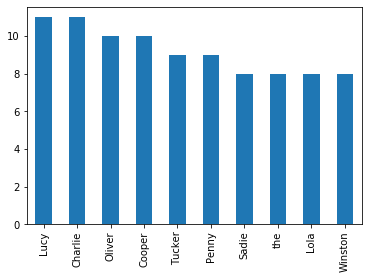

```python
common_names.plot.bar()
```

- Charlie , Lucy have the highest number.

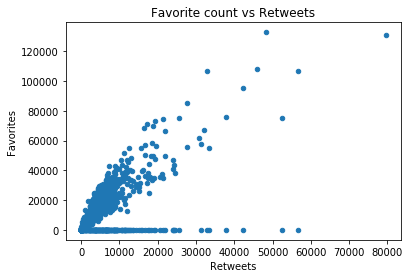

```python
#Compare retweet vs favorite count
tweet_clean.plot('retweet_count','favorite_count', kind='scatter')
plt.xlabel('Retweets')
plt.ylabel('Favorites')
plt.title('Favorite count vs Retweets');
```

- There is a positive correlation between retweets and favorite counts but favorite counts seem to be higher than retweets.

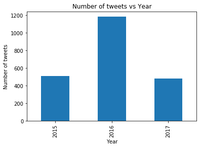

```python
#Compare the count of tweets in each year
tweet_archive_clean.timestamp = pd.to_datetime(tweet_archive.timestamp)
tweet_archive_clean.groupby(tweet_archive_clean.timestamp.dt.year)['index'].count().plot(kind='bar')
plt.xlabel('Year')
plt.ylabel('Number of tweets')
plt.title('Number of tweets vs Year');
```

- 2016 seems to be the most active year in the We Rate Dogs account history with more than 1000 tweets.